# Bayesian Analysis of GHG Fluxes in Seasonal Wetlands

Larissa Verona & David Herrera

2026-05-28

This script fits a hierarchical Bayesian framework to understand the drivers of CO₂ and CH₄ fluxes in seasonal wetland gradients. The causal chain tested is:

> **Climate + Topography → Soil Moisture → GHG Fluxes**

## 1. Libraries

```r
library(tidyverse)
library(lubridate)
library(brms)
library(tidybayes)
library(bayesplot)
library(patchwork)
library(cowplot)      # for get_legend() and plot_grid() in section 8d
library(viridis)
library(ggcorrplot)

# nicer bayesplot theme
bayesplot_theme_set(theme_classic(base_size = 12))
color_scheme_set("viridis")
```

## 2. Data Loading

We replicate the data preparation from `PreliminarAnalyses.Rmd` in a condensed, self-contained block so this script can be run independently.

```r
# ── helper: read one flux CSV (handles both sep=";" and sep=",") ──────────────
read_flux <- function(path, sep = ";", area_label, month_label,
                      datetime_fn = dmy_hm) {
  df <- read.csv(path, sep = sep, skip = 1) %>% slice(-1)
  # normalise the datetime column name (varies across campaigns)
  if ("DATE_TIME.initial_value" %in% names(df)) {
    df <- df %>% rename(datetime = DATE_TIME.initial_value)
  } else if (!"datetime" %in% names(df)) {
    # last resort: use the first column
    names(df)[1] <- "datetime"
  }
  df %>%
    mutate(area     = area_label,
           month    = month_label,
           datetime = datetime_fn(datetime))
}

# ── field campaigns (sep=";") ─────────────────────────────────────────────────
campaigns_semi <- list(
  list("Data/FluxProcessed/vvt_set24.csv",   "vvt",   "set24"),
  list("Data/FluxProcessed/7q_set24.csv",    "seteq", "set24"),
  list("Data/FluxProcessed/bbt_set24.csv",   "bbt",   "set24"),
  list("Data/FluxProcessed/cr_set24.csv",    "cr",    "set24"),
  list("Data/FluxProcessed/ing_set24.csv",   "ing",   "set24"),
  list("Data/FluxProcessed/vvt_nov24.csv",   "vvt",   "nov24"),
  list("Data/FluxProcessed/7q_nov24.csv",    "seteq", "nov24"),
  list("Data/FluxProcessed/bbt_nov24.csv",   "bbt",   "nov24"),
  list("Data/FluxProcessed/cr_nov24.csv",    "cr",    "nov24"),
  list("Data/FluxProcessed/ing_nov24.csv",   "ing",   "nov24"),
  list("Data/FluxProcessed/vvt_fev25.csv",   "vvt",   "fev25"),
  list("Data/FluxProcessed/7q_fev25.csv",    "seteq", "fev25"),
  list("Data/FluxProcessed/bbt_fev25.csv",   "bbt",   "fev25"),
  list("Data/FluxProcessed/cr_fev25.csv",    "cr",    "fev25"),
  list("Data/FluxProcessed/ing_fev25.csv",   "ing",   "fev25"),
  list("Data/FluxProcessed/vvt_jun25.csv",   "vvt",   "jun25"),
  list("Data/FluxProcessed/7q_jun25.csv",    "seteq", "jun25"),
  list("Data/FluxProcessed/bbt_jun25.csv",   "bbt",   "jun25"),
  list("Data/FluxProcessed/cr_jun25.csv",    "cr",    "jun25"),
  list("Data/FluxProcessed/ing_jun25.csv",   "ing",   "jun25"),
  list("Data/FluxProcessed/vvt_set25.csv",   "vvt",   "set25"),
  list("Data/FluxProcessed/7q_set25.csv",    "seteq", "set25"),
  list("Data/FluxProcessed/bbt_set25.csv",   "bbt",   "set25"),
  list("Data/FluxProcessed/cr_set25.csv",    "cr",    "set25"),
  list("Data/FluxProcessed/ing_set25.csv",   "ing",   "set25")
)

df_semi <- map_dfr(campaigns_semi, function(x)
  read_flux(x[[1]], sep = ";", area_label = x[[2]], month_label = x[[3]],
            datetime_fn = dmy_hm))

# ── december 2025 (sep=",", different datetime column) ───────────────────────
campaigns_comma <- list(
  list("Data/FluxProcessed/vvt_dez25.csv",   "vvt",   "dez25"),
  list("Data/FluxProcessed/7q_dez25.csv",    "seteq", "dez25"),
  list("Data/FluxProcessed/bbt_dez25.csv",   "bbt",   "dez25"),
  list("Data/FluxProcessed/cr_dez25.csv",    "cr",    "dez25"),
  list("Data/FluxProcessed/ing_dez25.csv",   "ing",   "dez25")
)

df_comma <- map_dfr(campaigns_comma, function(x)
  read_flux(x[[1]], sep = ",", area_label = x[[2]], month_label = x[[3]],
            datetime_fn = ymd_hms))

# ── merge and rename key columns ──────────────────────────────────────────────
df <- bind_rows(df_semi, df_comma) %>%
  mutate_at(vars(3, 4, 7:14), as.numeric) %>%
  rename(point = COMMENT,
         swc   = SWC_2.mean,
         ts    = TS_2.mean,
         fch4  = FCH4_DRY,
         fco2  = FCO2_DRY) %>%
  mutate(
    fch4_nmol = (fch4 / 1000) * 86400,
    month = factor(month,
                   levels = c("set24","nov24","fev25","jun25","set25","dez25")),
    area  = factor(area),
    point = factor(point,
                   levels = paste0("P", 1:10))
  )
```

```r
# ── soil properties ───────────────────────────────────────────────────────────
solos <- read.csv("Data/Soils/Soil.csv", sep = ";")
df    <- left_join(df, solos, by = c("area", "point"))

# ── HAND (topographic wetness / height above nearest drainage) ────────────────
hand <- read.csv("Data/Hand/Flux_points_HAND.csv", sep = ";") %>%
  select(area, point, hand) %>%
  group_by(area) %>%
  mutate(hand_p = (hand - min(hand, na.rm = TRUE)) /
                  (max(hand, na.rm = TRUE) - min(hand, na.rm = TRUE))) %>%
  ungroup()

df <- left_join(df, hand, by = c("area", "point")) %>%
  mutate(area  = factor(area),
         point = factor(point, levels = paste0("P", 1:10)))

# ── monthly precipitation (WorldClim) ─────────────────────────────────────────
prep <- read.csv("Data/Preciptation/prep_2010-2024_worldclim.csv") %>%
  select(mes, prec) %>%
  rename(month_num = mes)

month_map <- c(set24 = 9, nov24 = 11, fev25 = 2, jun25 = 6,
               set25 = 9, dez25 = 12)

df <- df %>%
  mutate(month_num = month_map[as.character(month)]) %>%
  left_join(prep, by = "month_num")

# ── unique point identifier for random effects ─────────────────────────────────
df <- df %>%
  mutate(point2 = paste(area, point))

cat("Rows:", nrow(df), "| Areas:", nlevels(df$area),
    "| Points:", length(unique(df$point2)),
    "| Campaigns:", nlevels(df$month), "\n")
```

```
## Rows: 274 | Areas: 5 | Points: 50 | Campaigns: 6
```

## 3. Analytical Dataset

We filter to rows with complete observations for all focal variables, log-transform the fluxes (CO₂ must be positive; CH₄ gets a +5 offset to handle near-zero/negative values), and standardise all continuous predictors to mean 0 / SD 1 for interpretable and efficient sampling.

```r
df_an <- df %>%
  select(fco2, fch4, swc, ts, hand, hand_p, prec, C,
         area, point, point2, month) %>%
  filter(fco2 > 0) %>%                         # log requires positive values
  mutate(
    log_fco2  = log(fco2),
    log_fch4  = log(fch4 + 5),                 # +5 shifts distribution positive
    swc_s     = as.numeric(scale(swc)),
    ts_s      = as.numeric(scale(ts)),
    hand_s    = as.numeric(scale(hand_p)),      # relative HAND within each area
    prec_s    = as.numeric(scale(prec)),
    C_s       = as.numeric(scale(C)),
    swc_beta  = pmin(pmax(swc, 1e-4), 1 - 1e-4),  # clamped to (0,1) strict for Beta regression
    fch4_pos  = fch4 + 5,                          # shifted to strictly positive for Gamma regression
    fch4_hurdle = if_else(fch4 <= 0, 0, fch4)     # true zeros for hurdle model: 0 = aerobic/no emission, >0 = active methanogenesis
  ) %>%
  drop_na(log_fco2, log_fch4, swc_s, ts_s, hand_s, prec_s)

cat("Analysis dataset:", nrow(df_an), "observations\n")
```

```
## Analysis dataset: 228 observations
```

### Quick overview

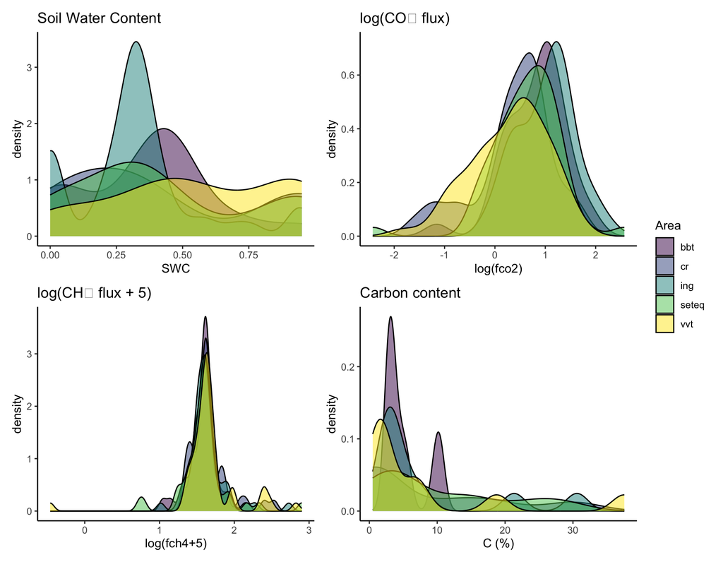

```r
# Distribution of key variables
p1 <- ggplot(df_an, aes(x = swc, fill = area)) +
  geom_density(alpha = 0.5) + scale_fill_viridis_d() +
  labs(title = "Soil Water Content", x = "SWC", fill = "Area") + theme_classic()

p2 <- ggplot(df_an, aes(x = log_fco2, fill = area)) +
  geom_density(alpha = 0.5) + scale_fill_viridis_d() +
  labs(title = "log(CO₂ flux)", x = "log(fco2)", fill = "Area") + theme_classic()

p3 <- ggplot(df_an, aes(x = log_fch4, fill = area)) +
  geom_density(alpha = 0.5) + scale_fill_viridis_d() +
  labs(title = "log(CH₄ flux + 5)", x = "log(fch4+5)", fill = "Area") + theme_classic()

p4 <- ggplot(df_an, aes(x = C, fill = area)) +
  geom_density(alpha = 0.5) + scale_fill_viridis_d() +
  labs(title = "Carbon content", x = "C (%)", fill = "Area") + theme_classic()

(p1 + p2) / (p3 + p4) + plot_layout(guides = "collect")
```

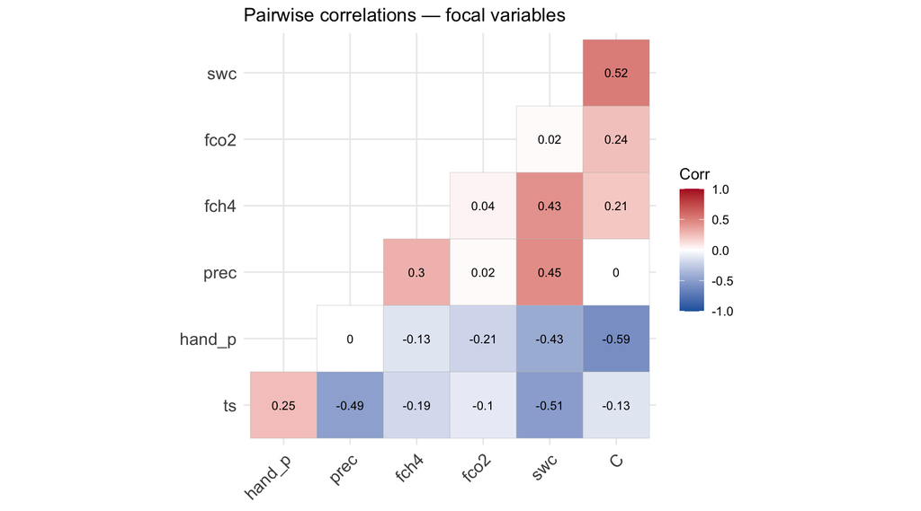

```r
df_an %>%
  select(swc, ts, hand_p, prec, C, fco2, fch4) %>%
  drop_na() %>%
  cor(use = "pairwise.complete.obs") %>%
  ggcorrplot(hc.order = TRUE, type = "lower", lab = TRUE, lab_size = 3,
             colors = c("#2166ac","white","#b2182b"),
             title = "Pairwise correlations — focal variables")
```

## 4. Model 1 — Drivers of Soil Moisture

**Question:** How do temperature, precipitation, and topographic position (HAND) drive soil moisture, and does this vary across wetland areas?

**Formula:** `swc ~ ts + prec + hand + (1 | area)`

```r
prior_swc <- c(
  prior(normal(0, 1),   class = "b"),          # slopes
  prior(normal(0, 1),   class = "Intercept"),   # global mean
  prior(exponential(1), class = "sd"),           # among-area SD
  prior(exponential(1), class = "sigma")         # residual SD
)

mod_swc_path <- "Data/mod_swc.rds"

if (file.exists(mod_swc_path)) {
  mod_swc <- readRDS(mod_swc_path)
} else {
  mod_swc <- brm(
    swc_s ~ ts_s + prec_s + hand_s + (1 | area),
    data    = df_an,
    family  = gaussian(),
    prior   = prior_swc,
    iter    = 4000,
    warmup  = 1000,
    chains  = 4,
    cores   = 4,
    seed    = 42,
    control = list(adapt_delta = 0.95)
  )
  saveRDS(mod_swc, mod_swc_path)
}
```

```r
summary(mod_swc)
```

```
##  Family: gaussian
##   Links: mu = identity; sigma = identity
## Formula: swc_s ~ ts_s + prec_s + hand_s + (1 | area)
##    Data: df_an (Number of observations: 228)
##   Draws: 4 chains, each with iter = 4000; warmup = 1000; thin = 1;
##          total post-warmup draws = 12000
##
## Multilevel Hyperparameters:
## ~area (Number of levels: 5)
##               Estimate Est.Error l-95% CI u-95% CI Rhat Bulk_ESS Tail_ESS
## sd(Intercept)     0.41      0.21     0.17     0.95 1.00     3430     5501
##
## Regression Coefficients:
##           Estimate Est.Error l-95% CI u-95% CI Rhat Bulk_ESS Tail_ESS
## Intercept    -0.03      0.20    -0.43     0.41 1.00     4005     4520
## ts_s         -0.25      0.06    -0.36    -0.14 1.00     9550     7980
## prec_s        0.32      0.06     0.22     0.43 1.00     9561     7608
## hand_s       -0.40      0.05    -0.50    -0.30 1.00    10409     7465
##
## Further Distributional Parameters:
##       Estimate Est.Error l-95% CI u-95% CI Rhat Bulk_ESS Tail_ESS
## sigma     0.71      0.03     0.65     0.78 1.00    10531     7622
##
## Draws were sampled using sampling(NUTS). For each parameter, Bulk_ESS
## and Tail_ESS are effective sample size measures, and Rhat is the potential
## scale reduction factor on split chains (at convergence, Rhat = 1).
```

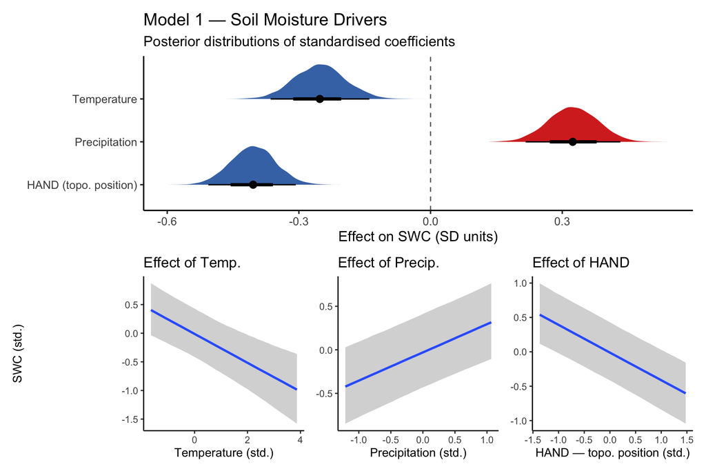

```r
# ── Posterior coefficient plot ─────────────────────────────────────────────────
post_swc <- as_draws_df(mod_swc) %>%
  select(starts_with("b_")) %>%
  pivot_longer(everything(), names_to = "parameter", values_to = "value") %>%
  filter(parameter != "b_Intercept") %>%
  mutate(parameter = recode(parameter,
    "b_ts_s"   = "Temperature",
    "b_prec_s" = "Precipitation",
    "b_hand_s" = "HAND (topo. position)"
  ))

p_swc_coef <- ggplot(post_swc, aes(x = value, y = parameter, fill = after_stat(x > 0))) +
  stat_halfeye(.width = c(0.66, 0.95), point_interval = median_hdi) +
  geom_vline(xintercept = 0, linetype = "dashed", colour = "grey40") +
  scale_fill_manual(values = c("#4575b4","#d73027"), guide = "none") +
  labs(title    = "Model 1 — Soil Moisture Drivers",
       subtitle = "Posterior distributions of standardised coefficients",
       x = "Effect on SWC (SD units)", y = NULL) +
  theme_classic(base_size = 13)

# ── Conditional effects ────────────────────────────────────────────────────────
ce_swc <- conditional_effects(mod_swc, effects = c("ts_s","prec_s","hand_s"),
                               re_formula = NA)  # marginalised over areas

p_ts   <- plot(ce_swc, plot = FALSE)[[1]] +
  labs(x = "Temperature (std.)", y = "SWC (std.)", title = "Effect of Temp.") +
  theme_classic()
p_prec <- plot(ce_swc, plot = FALSE)[[2]] +
  labs(x = "Precipitation (std.)", y = NULL, title = "Effect of Precip.") +
  theme_classic()
p_hand <- plot(ce_swc, plot = FALSE)[[3]] +
  labs(x = "HAND — topo. position (std.)", y = NULL, title = "Effect of HAND") +
  theme_classic()

p_swc_coef / (p_ts + p_prec + p_hand)
```

```r
ggsave("Plots/Bayes_M1_SoilMoisture.pdf", width = 10, height = 8)
```

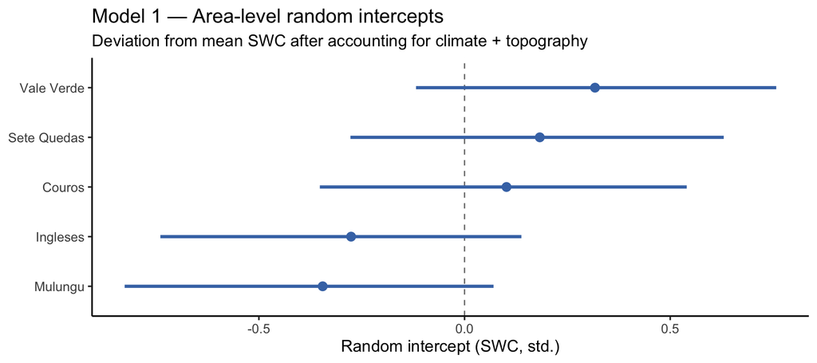

```r
# ── Random effects: how much does each area differ? ───────────────────────────
ranef_swc <- ranef(mod_swc)$area %>%
  as.data.frame() %>%
  rownames_to_column("area") %>%
  rename(est = Estimate.Intercept,
         lo  = Q2.5.Intercept,
         hi  = Q97.5.Intercept) %>%
  mutate(area = recode(area,
    vvt   = "Vale Verde",   bbt = "Mulungu",
    cr    = "Couros",       ing = "Ingleses",
    seteq = "Sete Quedas"
  ))

ggplot(ranef_swc, aes(x = reorder(area, est), y = est, ymin = lo, ymax = hi)) +
  geom_hline(yintercept = 0, linetype = "dashed", colour = "grey50") +
  geom_linerange(size = 1.2, colour = "#4575b4") +
  geom_point(size = 3, colour = "#4575b4") +
  coord_flip() +
  labs(title    = "Model 1 — Area-level random intercepts",
       subtitle = "Deviation from mean SWC after accounting for climate + topography",
       x = NULL, y = "Random intercept (SWC, std.)") +
  theme_classic(base_size = 13)
```

```r
ggsave("Plots/Bayes_M1_AreaRanef.pdf", width = 7, height = 4)
```

## 4b. Model 1b — Beta regression for bounded SWC *(NEW)*

```r
# ── NEW (4b): Beta regression for SWC as a bounded [0,1] outcome ──────────────
# swc_beta is swc clamped to (1e-4, 1-1e-4) so Beta() is well-defined.
# Predictors remain standardised; only the family changes.
prior_swc_beta <- c(
  prior(normal(0, 1),   class = "b"),
  prior(normal(0, 2),   class = "Intercept"),
  prior(exponential(1), class = "sd"),
  prior(exponential(1), class = "phi")      # Beta precision: larger = less dispersion
)

# ── cache name updated (_month) so a fresh fit is triggered automatically ─────
mod_swc_beta_path <- "Data/mod_swc_beta_month.rds"

if (file.exists(mod_swc_beta_path)) {
  mod_swc_beta <- readRDS(mod_swc_beta_path)
} else {
  mod_swc_beta <- brm(
    # (1|month) added: each campaign gets its own SWC intercept,
    # capturing the dry-season / wet-season bimodality seen in pp_check.
    swc_beta ~ ts_s + prec_s + hand_s + (1 | area) + (1 | month),
    data    = df_an,
    family  = Beta(),
    prior   = c(prior_swc_beta,
                prior(exponential(1), class = "sd", group = "month")),
    iter    = 4000,
    warmup  = 1000,
    chains  = 4,
    cores   = 4,
    seed    = 42,
    control = list(adapt_delta = 0.97)   # slightly higher for extra RE
  )
  saveRDS(mod_swc_beta, mod_swc_beta_path)
}
```

```r
# ── NEW (4b): summary — b coefficients on logit(SWC) scale ───────────────────
summary(mod_swc_beta)
```

[output not shown]

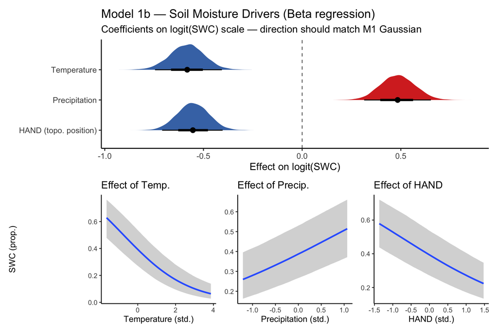

```r
# ── NEW (4b): posterior coefficient plot ──────────────────────────────────────
post_swc_beta <- as_draws_df(mod_swc_beta) %>%
  select(starts_with("b_")) %>%
  pivot_longer(everything(), names_to = "parameter", values_to = "value") %>%
  filter(parameter != "b_Intercept") %>%
  mutate(parameter = recode(parameter,
    "b_ts_s"   = "Temperature",
    "b_prec_s" = "Precipitation",
    "b_hand_s" = "HAND (topo. position)"
  ))

p_swc_beta_coef <- ggplot(post_swc_beta,
       aes(x = value, y = parameter, fill = after_stat(x > 0))) +
  stat_halfeye(.width = c(0.66, 0.95), point_interval = median_hdi) +
  geom_vline(xintercept = 0, linetype = "dashed", colour = "grey40") +
  scale_fill_manual(values = c("#4575b4","#d73027"), guide = "none") +
  labs(title    = "Model 1b — Soil Moisture Drivers (Beta regression)",
       subtitle = "Coefficients on logit(SWC) scale — direction should match M1 Gaussian",
       x = "Effect on logit(SWC)", y = NULL) +
  theme_classic(base_size = 13)

# conditional_effects back-transforms to the [0,1] scale automatically
ce_swc_beta <- conditional_effects(mod_swc_beta,
                                   effects    = c("ts_s","prec_s","hand_s"),
                                   re_formula = NA)

p_ts_b   <- plot(ce_swc_beta, plot = FALSE)[[1]] +
  labs(x = "Temperature (std.)", y = "SWC (prop.)", title = "Effect of Temp.") +
  theme_classic()
p_prec_b <- plot(ce_swc_beta, plot = FALSE)[[2]] +
  labs(x = "Precipitation (std.)", y = NULL, title = "Effect of Precip.") +
  theme_classic()
p_hand_b <- plot(ce_swc_beta, plot = FALSE)[[3]] +
  labs(x = "HAND (std.)", y = NULL, title = "Effect of HAND") +
  theme_classic()

p_swc_beta_coef / (p_ts_b + p_prec_b + p_hand_b)
```

```r
ggsave("Plots/Bayes_M1b_SWC_Beta.pdf", width = 10, height = 8)
```

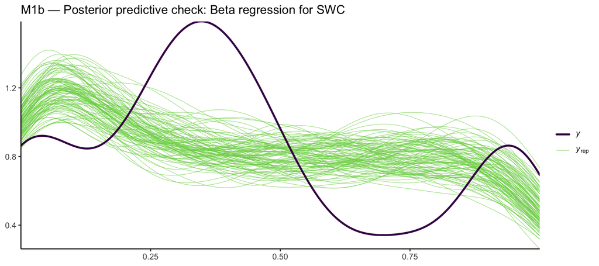

```r
# ── NEW (4b): posterior predictive check — does Beta capture the [0,1] shape? ─
pp_check(mod_swc_beta, ndraws = 100) +
  ggtitle("M1b — Posterior predictive check: Beta regression for SWC") +
  theme_classic()
```

## 5. Model 2 — CO₂ Flux Drivers

**Question:** How does soil moisture (and temperature and topography) drive CO₂ emissions, and does this vary by point, area, and season?

**Formula:** `log(fco2) ~ swc + ts + hand + (1|area) + (1|point2) + (1|month)`

```r
prior_flux <- c(
  prior(normal(0, 1),   class = "b"),
  prior(normal(0, 2),   class = "Intercept"),
  prior(exponential(1), class = "sd"),
  prior(exponential(1), class = "sigma")
)

mod_co2_path <- "Data/mod_co2.rds"

if (file.exists(mod_co2_path)) {
  mod_co2 <- readRDS(mod_co2_path)
} else {
  mod_co2 <- brm(
    log_fco2 ~ swc_s + ts_s + hand_s + (1 | area) + (1 | point2) + (1 | month),
    data    = df_an,
    family  = gaussian(),
    prior   = prior_flux,
    iter    = 4000,
    warmup  = 1000,
    chains  = 4,
    cores   = 4,
    seed    = 42,
    control = list(adapt_delta = 0.95)
  )
  saveRDS(mod_co2, mod_co2_path)
}
```

```r
summary(mod_co2)
```

```
##  Family: gaussian
##   Links: mu = identity; sigma = identity
## Formula: log_fco2 ~ swc_s + ts_s + hand_s + (1 | area) + (1 | point2) + (1 | month)
##    Data: df_an (Number of observations: 228)
##   Draws: 4 chains, each with iter = 4000; warmup = 1000; thin = 1;
##          total post-warmup draws = 12000
##
## Multilevel Hyperparameters:
## ~area (Number of levels: 5)
##               Estimate Est.Error l-95% CI u-95% CI Rhat Bulk_ESS Tail_ESS
## sd(Intercept)     0.22      0.17     0.01     0.66 1.00     2404     4055
##
## ~month (Number of levels: 6)
##               Estimate Est.Error l-95% CI u-95% CI Rhat Bulk_ESS Tail_ESS
## sd(Intercept)     0.26      0.16     0.03     0.64 1.00     2666     3343
##
## ~point2 (Number of levels: 46)
##               Estimate Est.Error l-95% CI u-95% CI Rhat Bulk_ESS Tail_ESS
## sd(Intercept)     0.43      0.07     0.30     0.59 1.00     3083     5804
##
## Regression Coefficients:
##           Estimate Est.Error l-95% CI u-95% CI Rhat Bulk_ESS Tail_ESS
## Intercept     0.62      0.19     0.25     1.00 1.00     5100     4746
## swc_s        -0.22      0.09    -0.40    -0.06 1.00     3759     7599
## ts_s          0.02      0.07    -0.12     0.16 1.00     5475     8452
## hand_s       -0.27      0.09    -0.44    -0.10 1.00     4026     6149
##
## Further Distributional Parameters:
##       Estimate Est.Error l-95% CI u-95% CI Rhat Bulk_ESS Tail_ESS
## sigma     0.56      0.03     0.50     0.62 1.00     6499     7957
##
## Draws were sampled using sampling(NUTS). For each parameter, Bulk_ESS
## and Tail_ESS are effective sample size measures, and Rhat is the potential
## scale reduction factor on split chains (at convergence, Rhat = 1).
```

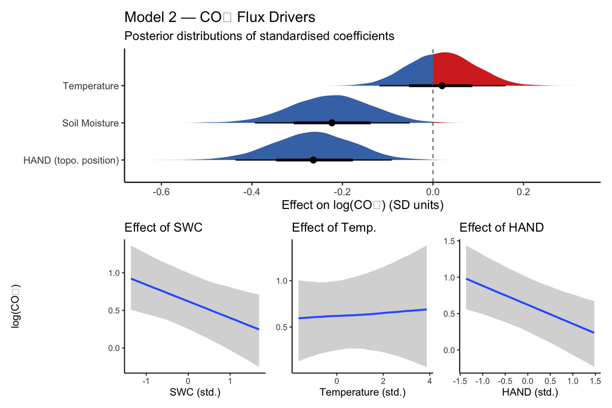

```r
post_co2 <- as_draws_df(mod_co2) %>%
  select(starts_with("b_")) %>%
  pivot_longer(everything(), names_to = "parameter", values_to = "value") %>%
  filter(parameter != "b_Intercept") %>%
  mutate(parameter = recode(parameter,
    "b_swc_s"  = "Soil Moisture",
    "b_ts_s"   = "Temperature",
    "b_hand_s" = "HAND (topo. position)"
  ))

p_co2_coef <- ggplot(post_co2, aes(x = value, y = parameter, fill = after_stat(x > 0))) +
  stat_halfeye(.width = c(0.66, 0.95), point_interval = median_hdi) +
  geom_vline(xintercept = 0, linetype = "dashed", colour = "grey40") +
  scale_fill_manual(values = c("#4575b4","#d73027"), guide = "none") +
  labs(title    = "Model 2 — CO₂ Flux Drivers",
       subtitle = "Posterior distributions of standardised coefficients",
       x = "Effect on log(CO₂) (SD units)", y = NULL) +
  theme_classic(base_size = 13)

ce_co2 <- conditional_effects(mod_co2,
                               effects  = c("swc_s","ts_s","hand_s"),
                               re_formula = NA)

p_swc2  <- plot(ce_co2, plot = FALSE)[[1]] +
  labs(x = "SWC (std.)", y = "log(CO₂)", title = "Effect of SWC") + theme_classic()
p_ts2   <- plot(ce_co2, plot = FALSE)[[2]] +
  labs(x = "Temperature (std.)", y = NULL, title = "Effect of Temp.") + theme_classic()
p_hand2 <- plot(ce_co2, plot = FALSE)[[3]] +
  labs(x = "HAND (std.)", y = NULL, title = "Effect of HAND") + theme_classic()

p_co2_coef / (p_swc2 + p_ts2 + p_hand2)
```

```r
ggsave("Plots/Bayes_M2_CO2_linear.pdf", width = 10, height = 8)
```

## 5b. Non-linear CO₂ ~ SWC relationship *(NEW)*

> **Fixes:** (1) a raw GAM smooth to confirm the curve exists in the data; (2) a Bayesian model with a quadratic SWC term; (3) formal model comparison with LOO-CV to verify the non-linearity is not just noise; (4) back-calculation of the optimum moisture point with full posterior uncertainty.

### Raw data check — GAM smooth by area *(NEW)*

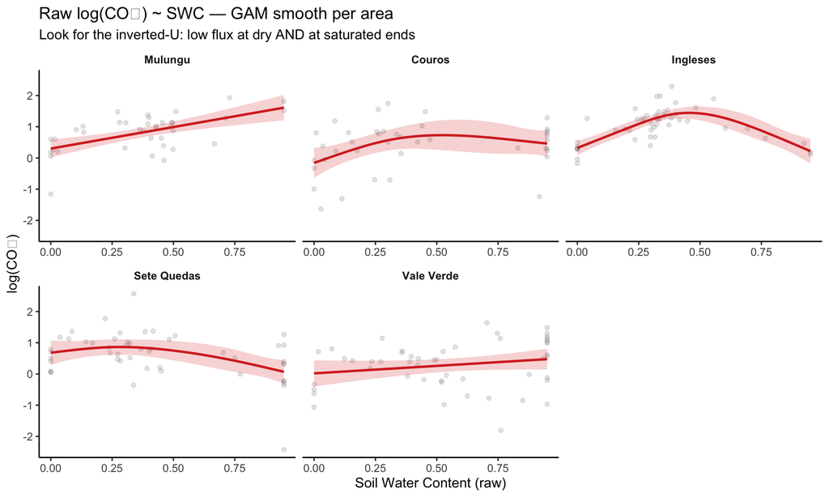

```r
# ── NEW: visualise the raw shape before fitting any model ─────────────────────
# A GAM smooth (k=5 knots) is flexible enough to reveal a parabola without
# over-fitting. If the inverted-U is real it should appear in most areas.
library(mgcv)   # for GAM; loaded here so it is explicit

ggplot(df_an, aes(x = swc, y = log_fco2)) +
  geom_point(alpha = 0.25, colour = "grey60", size = 1.5) +
  geom_smooth(method = "gam", formula = y ~ s(x, k = 5),
              colour = "#d73027", fill = "#d73027", alpha = 0.2, linewidth = 1) +
  facet_wrap(~area, scales = "free_x",
             labeller = as_labeller(c(vvt   = "Vale Verde",
                                      bbt   = "Mulungu",
                                      cr    = "Couros",
                                      ing   = "Ingleses",
                                      seteq = "Sete Quedas"))) +
  labs(title    = "Raw log(CO₂) ~ SWC — GAM smooth per area",
       subtitle = "Look for the inverted-U: low flux at dry AND at saturated ends",
       x = "Soil Water Content (raw)", y = "log(CO₂)") +
  theme_classic(base_size = 12) +
  theme(strip.background = element_blank(),
        strip.text = element_text(face = "bold"))
```

```r
ggsave("Plots/Bayes_CO2_GAM_check.pdf", width = 10, height = 6)
```

### Model 2b — quadratic CO₂ model *(NEW)*

**Formula:** `log(fco2) ~ swc + swc² + ts + hand + (1|area) + (1|point2) + (1|month)`

The quadratic term `I(swc_s^2)` captures the curvature. A **negative** posterior for this coefficient confirms the inverted-U (peak somewhere in the middle of the SWC range); a positive coefficient would indicate a U-shape (rare ecologically).

```r
# ── NEW: fit quadratic model and cache ────────────────────────────────────────
mod_co2_quad_path <- "Data/mod_co2_quad.rds"

if (file.exists(mod_co2_quad_path)) {
  mod_co2_quad <- readRDS(mod_co2_quad_path)
} else {
  mod_co2_quad <- brm(
    # swc_s² added alongside the linear term
    log_fco2 ~ swc_s + I(swc_s^2) + ts_s + hand_s +
               (1 | area) + (1 | point2) + (1 | month),
    data    = df_an,
    family  = gaussian(),
    prior   = prior_flux,          # same weakly-informative priors as M2
    iter    = 4000,
    warmup  = 1000,
    chains  = 4,
    cores   = 4,
    seed    = 42,
    control = list(adapt_delta = 0.95)
  )
  saveRDS(mod_co2_quad, mod_co2_quad_path)
}
```

```r
# ── NEW: summarise quadratic model ────────────────────────────────────────────
# Key things to look at:
#   b_swc_s       → linear slope (positive = generally rising with moisture)
#   b_Iswc_sE2    → curvature (negative = inverted-U, i.e. a peak exists)
summary(mod_co2_quad)
```

```
##  Family: gaussian
##   Links: mu = identity; sigma = identity
## Formula: log_fco2 ~ swc_s + I(swc_s^2) + ts_s + hand_s + (1 | area) + (1 | point2) + (1 | month)
##    Data: df_an (Number of observations: 228)
##   Draws: 4 chains, each with iter = 4000; warmup = 1000; thin = 1;
##          total post-warmup draws = 12000
##
## Multilevel Hyperparameters:
## ~area (Number of levels: 5)
##               Estimate Est.Error l-95% CI u-95% CI Rhat Bulk_ESS Tail_ESS
## sd(Intercept)     0.21      0.17     0.01     0.65 1.00     1079      389
##
## ~month (Number of levels: 6)
##               Estimate Est.Error l-95% CI u-95% CI Rhat Bulk_ESS Tail_ESS
## sd(Intercept)     0.11      0.09     0.00     0.33 1.00     3613     5243
##
## ~point2 (Number of levels: 46)
##               Estimate Est.Error l-95% CI u-95% CI Rhat Bulk_ESS Tail_ESS
## sd(Intercept)     0.44      0.07     0.32     0.59 1.00     3035     5451
##
## Regression Coefficients:
##           Estimate Est.Error l-95% CI u-95% CI Rhat Bulk_ESS Tail_ESS
## Intercept     0.92      0.17     0.56     1.22 1.01      971      328
## swc_s         0.03      0.07    -0.12     0.17 1.00     4757     6958
## Iswc_sE2     -0.31      0.04    -0.39    -0.22 1.00    10143     9424
## ts_s          0.10      0.06    -0.01     0.22 1.00     8068     8352
## hand_s       -0.25      0.08    -0.41    -0.10 1.00     2373     3325
##
## Further Distributional Parameters:
##       Estimate Est.Error l-95% CI u-95% CI Rhat Bulk_ESS Tail_ESS
## sigma     0.50      0.03     0.45     0.56 1.00     8410     9113
##
## Draws were sampled using sampling(NUTS). For each parameter, Bulk_ESS
## and Tail_ESS are effective sample size measures, and Rhat is the potential
## scale reduction factor on split chains (at convergence, Rhat = 1).
```

### Posterior coefficient plot — quadratic model *(NEW)*

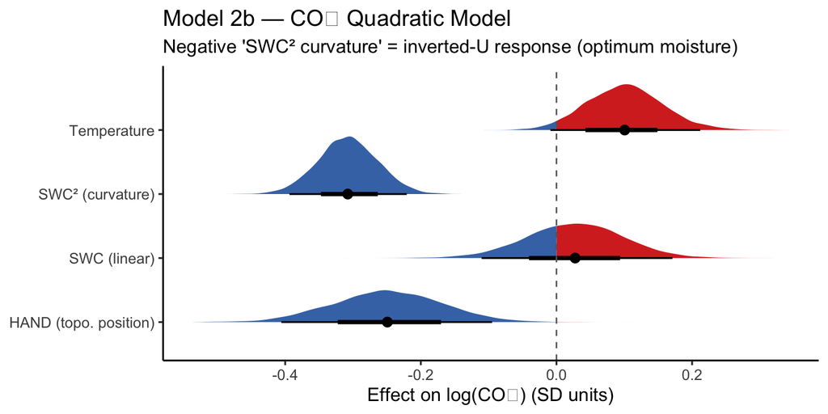

```r
# ── NEW: extract and plot posteriors for the quadratic model ──────────────────
post_co2_quad <- as_draws_df(mod_co2_quad) %>%
  select(starts_with("b_")) %>%
  pivot_longer(everything(), names_to = "parameter", values_to = "value") %>%
  filter(parameter != "b_Intercept") %>%
  mutate(parameter = recode(parameter,
    "b_swc_s"      = "SWC (linear)",
    "b_Iswc_sE2"   = "SWC² (curvature)",   # negative = inverted-U
    "b_ts_s"       = "Temperature",
    "b_hand_s"     = "HAND (topo. position)"
  ))

ggplot(post_co2_quad,
       aes(x = value, y = parameter, fill = after_stat(x > 0))) +
  stat_halfeye(.width = c(0.66, 0.95), point_interval = median_hdi) +
  geom_vline(xintercept = 0, linetype = "dashed", colour = "grey40") +
  scale_fill_manual(values = c("#4575b4","#d73027"), guide = "none") +
  labs(title    = "Model 2b — CO₂ Quadratic Model",
       subtitle = "Negative 'SWC² curvature' = inverted-U response (optimum moisture)",
       x = "Effect on log(CO₂) (SD units)", y = NULL) +
  theme_classic(base_size = 13)
```

```r
ggsave("Plots/Bayes_M2b_CO2_quad_coef.pdf", width = 8, height = 4)
```

### Optimal SWC — where is the CO₂ peak? *(NEW)*

```r
# ── NEW: back-calculate the SWC peak from the posterior ───────────────────────
# For y = b1*x + b2*x², the vertex (peak) is at x* = -b1 / (2*b2).
# We compute this for every posterior draw to get full uncertainty on the peak.

swc_mean <- mean(df_an$swc, na.rm = TRUE)
swc_sd   <- sd(df_an$swc,   na.rm = TRUE)

peak_draws <- as_draws_df(mod_co2_quad) %>%
  mutate(
    peak_scaled = -b_swc_s / (2 * b_Iswc_sE2),   # peak on standardised scale
    peak_raw    = peak_scaled * swc_sd + swc_mean  # back to raw SWC units
  )

cat(sprintf(
  "Estimated SWC optimum for CO₂: %.3f  [95%% CI: %.3f, %.3f]\n",
  median(peak_draws$peak_raw),
  quantile(peak_draws$peak_raw, 0.025),
  quantile(peak_draws$peak_raw, 0.975)
))
```

```
## Estimated SWC optimum for CO₂: 0.438  [95% CI: 0.355, 0.501]
```

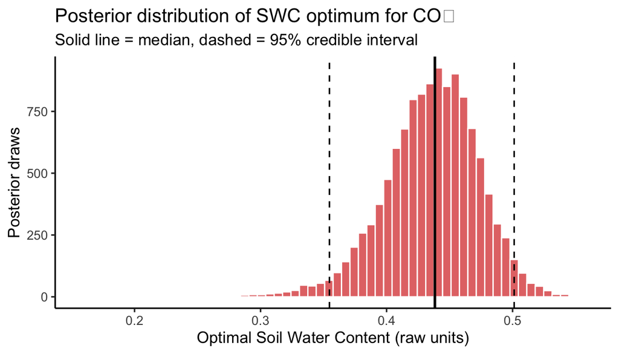

```r
# Plot the posterior distribution of the peak
ggplot(peak_draws, aes(x = peak_raw)) +
  geom_histogram(bins = 60, fill = "#d73027", alpha = 0.7, colour = "white") +
  geom_vline(xintercept = median(peak_draws$peak_raw),
             colour = "black", linewidth = 1) +
  geom_vline(xintercept = quantile(peak_draws$peak_raw, c(0.025, 0.975)),
             colour = "black", linewidth = 0.6, linetype = "dashed") +
  labs(title    = "Posterior distribution of SWC optimum for CO₂",
       subtitle = "Solid line = median, dashed = 95% credible interval",
       x = "Optimal Soil Water Content (raw units)", y = "Posterior draws") +
  theme_classic(base_size = 13)
```

```r
ggsave("Plots/Bayes_CO2_SWC_optimum.pdf", width = 7, height = 4)
```

### Fitted curve with peak annotation *(NEW)*

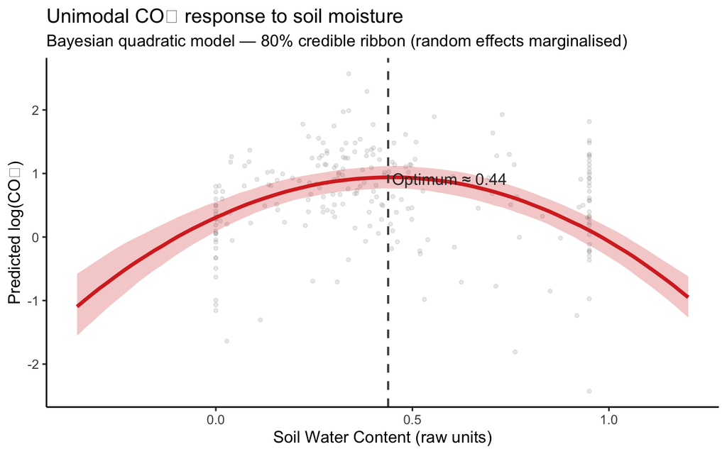

```r
# ── NEW: plot the fitted quadratic curve with credible ribbon ─────────────────
# We predict along the full SWC range, marginalising over all random effects.
swc_seq <- seq(-2.5, 2.5, length.out = 80)

pred_quad <- expand_grid(
  swc_s  = swc_seq,
  ts_s   = 0,       # held at mean temperature
  hand_s = 0,       # held at mean HAND
  area   = unique(df_an$area)[1],
  point2 = unique(df_an$point2)[1],
  month  = unique(df_an$month)[1]
) %>%
  add_epred_draws(mod_co2_quad, ndraws = 500, re_formula = NA) %>%
  group_by(swc_s) %>%
  summarise(med = median(.epred),
            lo  = quantile(.epred, 0.10),
            hi  = quantile(.epred, 0.90),
            .groups = "drop") %>%
  mutate(swc_raw = swc_s * swc_sd + swc_mean)   # back to original units for x-axis

peak_med <- median(peak_draws$peak_raw)

ggplot(pred_quad, aes(x = swc_raw)) +
  # raw data in background
  geom_point(data = df_an, aes(x = swc, y = log_fco2),
             alpha = 0.2, colour = "grey60", size = 1.2, inherit.aes = FALSE) +
  # credible ribbon + fitted line
  geom_ribbon(aes(ymin = lo, ymax = hi), alpha = 0.25, fill = "#d73027") +
  geom_line(aes(y = med), colour = "#d73027", linewidth = 1.4) +
  # peak annotation
  geom_vline(xintercept = peak_med,
             linetype = "dashed", colour = "grey30", linewidth = 0.8) +
  annotate("text",
           x     = peak_med + 0.01,
           y     = max(pred_quad$med) * 0.97,
           label = sprintf("Optimum ≈ %.2f", peak_med),
           hjust = 0, colour = "grey20", size = 4.5) +
  labs(title    = "Unimodal CO₂ response to soil moisture",
       subtitle = "Bayesian quadratic model — 80% credible ribbon (random effects marginalised)",
       x        = "Soil Water Content (raw units)",
       y        = "Predicted log(CO₂)") +
  theme_classic(base_size = 13)
```

```r
ggsave("Plots/Bayes_M2b_CO2_quad_curve.pdf", width = 8, height = 5)
```

### Model comparison: linear vs. quadratic *(NEW)*

```r
# ── NEW: LOO-CV comparison — is the quadratic significantly better? ────────────
# elpd_diff > 0 for the first row (best model); a |diff| >> SE means clear win.
mod_co2      <- add_criterion(mod_co2,      "loo")
mod_co2_quad <- add_criterion(mod_co2_quad, "loo")
cat("=== LOO-CV comparison: linear (M2) vs. quadratic (M2b) ===\n")
```

```
## === LOO-CV comparison: linear (M2) vs. quadratic (M2b) ===
```

```r
print(loo_compare(mod_co2, mod_co2_quad))
```

```
##              elpd_diff se_diff
## mod_co2_quad   0.0       0.0
## mod_co2      -21.6       6.7
```

```r
cat("\nIf M2b (quadratic) is in row 1, it fits better.\n")
```

```
##
## If M2b (quadratic) is in row 1, it fits better.
```

```r
cat("A |elpd_diff| > 2 × se_diff is considered substantial.\n")
```

```
## A |elpd_diff| > 2 × se_diff is considered substantial.
```

## 5c. Model 2c — CO₂ with organic carbon predictor *(NEW)*

> **Motivation:** Temperature and season are correlated — `ts_s` partly captures seasonal effects already absorbed by the `(1|month)` random intercept. Replacing it with **soil organic carbon (C%)** asks a complementary question: does the *substrate pool* (long-term C accumulation driven by hydrology and productivity) explain flux variation beyond topography and moisture alone? C% is measured once per point, so it captures spatial — not temporal — heterogeneity.

> **Formula:** `log(fco2) ~ swc + swc² + C + hand + (1|area) + (1|point2) + (1|month)`

```r
# ── NEW (5c): CO₂ quadratic model with organic carbon replacing temperature ─────
# Using drop_na(C_s) inside data= keeps the model self-consistent without
# modifying df_an (so M2/M2b remain comparable on their original dataset).
mod_co2_C_path <- "Data/mod_co2_C.rds"

if (file.exists(mod_co2_C_path)) {
  mod_co2_C <- readRDS(mod_co2_C_path)
} else {
  mod_co2_C <- brm(
    log_fco2 ~ swc_s + I(swc_s^2) + C_s + hand_s +
               (1 | area) + (1 | point2) + (1 | month),
    data    = df_an %>% drop_na(C_s),
    family  = gaussian(),
    prior   = prior_flux,           # same weakly-informative priors as M2/M2b
    iter    = 4000,
    warmup  = 1000,
    chains  = 4,
    cores   = 4,
    seed    = 42,
    control = list(adapt_delta = 0.95)
  )
  saveRDS(mod_co2_C, mod_co2_C_path)
}
```

```r
# ── NEW (5c): summary ─────────────────────────────────────────────────────────
cat("n =", nrow(df_an %>% drop_na(C_s)), "observations with soil C data\n")
```

```
## n = 228 observations with soil C data
```

```r
summary(mod_co2_C)
```

```
##  Family: gaussian
##   Links: mu = identity; sigma = identity
## Formula: log_fco2 ~ swc_s + I(swc_s^2) + C_s + hand_s + (1 | area) + (1 | point2) + (1 | month)
##    Data: df_an %>% drop_na(C_s) (Number of observations: 228)
##   Draws: 4 chains, each with iter = 4000; warmup = 1000; thin = 1;
##          total post-warmup draws = 12000
##
## Multilevel Hyperparameters:
## ~area (Number of levels: 5)
##               Estimate Est.Error l-95% CI u-95% CI Rhat Bulk_ESS Tail_ESS
## sd(Intercept)     0.21      0.16     0.01     0.63 1.00     1956     3105
##
## ~month (Number of levels: 6)
##               Estimate Est.Error l-95% CI u-95% CI Rhat Bulk_ESS Tail_ESS
## sd(Intercept)     0.08      0.07     0.00     0.26 1.00     3828     4646
##
## ~point2 (Number of levels: 46)
##               Estimate Est.Error l-95% CI u-95% CI Rhat Bulk_ESS Tail_ESS
## sd(Intercept)     0.39      0.06     0.28     0.52 1.00     3726     6201
##
## Regression Coefficients:
##           Estimate Est.Error l-95% CI u-95% CI Rhat Bulk_ESS Tail_ESS
## Intercept     0.92      0.14     0.62     1.21 1.00     4237     4497
## swc_s        -0.05      0.06    -0.18     0.06 1.00     6457     6282
## Iswc_sE2     -0.29      0.04    -0.37    -0.21 1.00    10901     8795
## C_s           0.28      0.09     0.10     0.46 1.00     4476     6089
## hand_s       -0.09      0.09    -0.26     0.09 1.00     4088     5842
##
## Further Distributional Parameters:
##       Estimate Est.Error l-95% CI u-95% CI Rhat Bulk_ESS Tail_ESS
## sigma     0.51      0.03     0.46     0.56 1.00    10072     8682
##
## Draws were sampled using sampling(NUTS). For each parameter, Bulk_ESS
## and Tail_ESS are effective sample size measures, and Rhat is the potential
## scale reduction factor on split chains (at convergence, Rhat = 1).
```

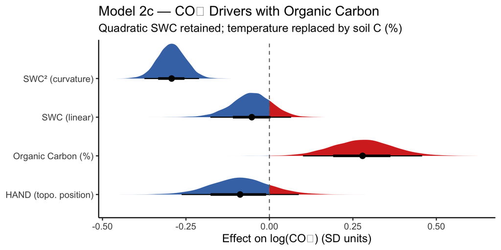

```r
# ── NEW (5c): posterior coefficient plot ──────────────────────────────────────
post_co2_C <- as_draws_df(mod_co2_C) %>%
  select(starts_with("b_")) %>%
  pivot_longer(everything(), names_to = "parameter", values_to = "value") %>%
  filter(parameter != "b_Intercept") %>%
  mutate(parameter = recode(parameter,
    "b_swc_s"    = "SWC (linear)",
    "b_Iswc_sE2" = "SWC² (curvature)",
    "b_C_s"      = "Organic Carbon (%)",
    "b_hand_s"   = "HAND (topo. position)"
  ))

ggplot(post_co2_C, aes(x = value, y = parameter, fill = after_stat(x > 0))) +
  stat_halfeye(.width = c(0.66, 0.95), point_interval = median_hdi) +
  geom_vline(xintercept = 0, linetype = "dashed", colour = "grey40") +
  scale_fill_manual(values = c("#4575b4","#d73027"), guide = "none") +
  labs(title    = "Model 2c — CO₂ Drivers with Organic Carbon",
       subtitle = "Quadratic SWC retained; temperature replaced by soil C (%)",
       x = "Effect on log(CO₂) (SD units)", y = NULL) +
  theme_classic(base_size = 13)
```

```r
ggsave("Plots/Bayes_M2c_CO2_Carbon_coef.pdf", width = 8, height = 4)
```

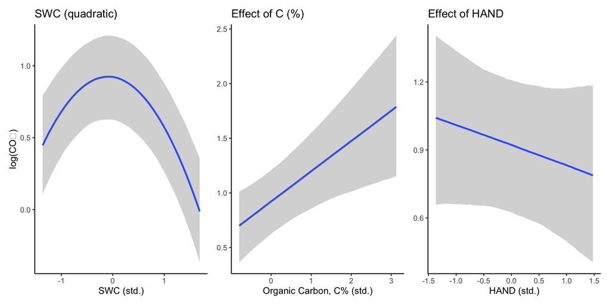

```r
# ── NEW (5c): conditional effects — SWC curve + carbon + HAND ────────────────
ce_co2_C <- conditional_effects(mod_co2_C,
                                 effects    = c("swc_s","C_s","hand_s"),
                                 re_formula = NA)

p_swc_c  <- plot(ce_co2_C, plot = FALSE)[[1]] +
  labs(x = "SWC (std.)", y = "log(CO₂)", title = "SWC (quadratic)") +
  theme_classic()
p_C_c    <- plot(ce_co2_C, plot = FALSE)[[2]] +
  labs(x = "Organic Carbon, C% (std.)", y = NULL, title = "Effect of C (%)") +
  theme_classic()
p_hand_c <- plot(ce_co2_C, plot = FALSE)[[3]] +
  labs(x = "HAND (std.)", y = NULL, title = "Effect of HAND") +
  theme_classic()

p_swc_c + p_C_c + p_hand_c
```

```r
ggsave("Plots/Bayes_M2c_CO2_Carbon_CE.pdf", width = 10, height = 4)
```